# Cox Proportional Hazards Model

Author

Halley Deleeuw and Jasmine Sawh

Published

July 26, 2026

## 1 Introduction

The Cox Proportional Hazards (Cox PH) model is a statistical method used for survival analysis. It is a semi-parametric estimator that focuses on the *hazard function*, which represents the instantaneous risk of an event occurring at a given time, given that the subject has survived up to that time (Cox 1972). It is widely used in fields such as medicine and epidemiology, where the outcome of interest is the time until an event such as death, relapse, or re-infection.

The purpose of the Cox PH model is to describe the relationship between one or more explanatory variables (covariates) and the hazard, while allowing for censored observations — subjects for whom the event has not occurred by the end of the study. The response in a survival model has two parts: an event indicator (did the event happen?) and a measure of time (how long until the event or until the subject was last observed) (Kaplan and Meier 1958).

In this report we apply the Cox PH model to the North Central Cancer Treatment Group (NCCTG) lung cancer data set (Loprinzi et al. 1994), which records survival times of patients with advanced lung cancer along with several clinical measurements. Our goal is to identify which patient characteristics are associated with the risk of death, to estimate the size of those effects as hazard ratios, and to check whether the model’s proportional-hazards assumption is reasonable for these data.

## 2 Methods

### 2.1 The hazard function and the Cox model

Survival analysis models the time $T$ until an event. Two related functions describe the distribution of $T$. The *survival function* $S(t) = P(T > t)$ gives the probability of surviving beyond time $t$. The *hazard function*

$$h(t) = \lim_{\Delta t \to 0} \frac{P(t \le T < t + \Delta t \mid T \ge t)}{\Delta t}$$

gives the instantaneous rate of the event at time $t$ for subjects still at risk. The Cox model (Cox 1972) specifies the hazard for a subject with covariate vector $\mathbf{x} = (x_1, \dots, x_p)$ as

$$h(t \mid \mathbf{x}) = h_0(t)\,\exp\!\left(\beta_1 x_1 + \beta_2 x_2 + \cdots + \beta_p x_p\right).
\tag{1}$$

Here $h_0(t)$ is the *baseline hazard* — an unspecified function of time shared by all subjects — and the exponential term scales that baseline up or down according to the covariates. Because $h_0(t)$ is left unspecified, the model is called *semi-parametric*: it makes no assumption about the shape of the baseline hazard over time, only about how covariates shift it.

### 2.2 Hazard ratios

The coefficients are estimated by maximizing Cox’s *partial likelihood*, which depends only on the order in which events occur and therefore does not require estimating $h_0(t)$ (Cox 1972). The quantity of interest is the *hazard ratio* (HR), $\exp(\beta_j)$, which compares the hazard for a one-unit increase in covariate $x_j$, holding the other covariates fixed:

- $\exp(\beta_j) > 1$: higher values of $x_j$ **increase** the hazard (worse survival);
- $\exp(\beta_j) < 1$: higher values of $x_j$ **decrease** the hazard (better survival);
- $\exp(\beta_j) = 1$: $x_j$ has no effect.

### 2.3 The proportional-hazards assumption

The name of the model comes from its central assumption: the ratio of hazards between any two subjects is **constant over time**. Equivalently, covariate effects do not change as time passes. If this assumption is violated, the estimated hazard ratios can be misleading (Abeysekera and Sooriyarachchi 2009). We assess it using the scaled Schoenfeld residuals (Schoenfeld 1982): under proportional hazards these residuals should show no trend against time, and the associated test (implemented as `cox.zph` in the `survival` package (Therneau 2024)) should be non-significant.

## 3 Analysis and Results

### 3.1 Data and visualization

The `lung` data set is included in the `survival` package (Therneau 2024). Each row is a patient; the outcome is time from study entry (in days) to death or censoring. The covariates we consider are age, sex, and two measures of performance status — the ECOG score (`ph.ecog`, higher = more impaired) and the physician-rated Karnofsky score (`ph.karno`, higher = better) — along with six-month weight loss (`wt.loss`).

```r
library(survival)
library(ggplot2)
library(knitr)

theme_set(theme_bw(base_size = 12))

# 'lung' ships with the survival package. status is coded 1 = censored,
# 2 = dead; recode to the 0/1 event indicator the models expect, and give
# sex readable labels.
lung$status_event <- lung$status - 1
lung$sex_f <- factor(lung$sex, levels = c(1, 2), labels = c("Male", "Female"))

kable(
  head(lung[, c("time", "status", "age", "sex_f", "ph.ecog", "ph.karno", "wt.loss")]),
  caption = "First six patients in the NCCTG lung cancer data set."
)
```

First six patients in the NCCTG lung cancer data set.

| time | status | age | sex_f | ph.ecog | ph.karno | wt.loss |
| --- | --- | --- | --- | --- | --- | --- |
| 306 | 2 | 74 | Male | 1 | 90 | NA |
| 455 | 2 | 68 | Male | 0 | 90 | 15 |
| 1010 | 1 | 56 | Male | 0 | 90 | 15 |
| 210 | 2 | 57 | Male | 1 | 90 | 11 |
| 883 | 2 | 60 | Male | 0 | 100 | 0 |
| 1022 | 1 | 74 | Male | 1 | 50 | 0 |

The data set contains 228 patients, of whom 165 died during follow-up (the remainder were censored). We begin by estimating the survival function with the Kaplan–Meier method (Kaplan and Meier 1958), overall and separately by sex.

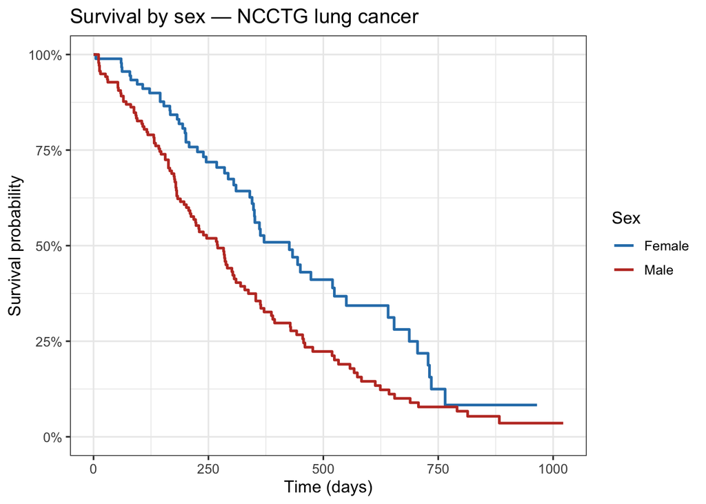

Kaplan–Meier survival curves by sex. Females (blue) survive longer than males (red).

```r
# Helper: turn a survfit object into a tidy data frame for ggplot.
tidy_surv <- function(fit) {
  strata <- if (is.null(fit$strata)) {
    rep("All", length(fit$time))
  } else {
    rep(sub(".*=", "", names(fit$strata)), fit$strata)
  }
  # Prepend the (time = 0, surv = 1) origin for each stratum so the step
  # curves start at 100% survival.
  origin <- data.frame(time = 0, surv = 1, strata = unique(strata))
  rbind(origin, data.frame(time = fit$time, surv = fit$surv, strata = strata))
}

km_sex <- survfit(Surv(time, status_event) ~ sex_f, data = lung)

ggplot(tidy_surv(km_sex), aes(time, surv, color = strata)) +
  geom_step(linewidth = 0.9) +
  scale_y_continuous(limits = c(0, 1), labels = scales::percent) +
  scale_color_manual(values = c(Male = "#c0392b", Female = "#2c7fb8")) +
  labs(x = "Time (days)", y = "Survival probability", color = "Sex",
       title = "Survival by sex — NCCTG lung cancer")
```

The curves separate clearly, with female patients maintaining higher survival probabilities throughout follow-up. A log-rank test formally compares the two groups:

```r
survdiff(Surv(time, status_event) ~ sex_f, data = lung)
```

```
Call:
survdiff(formula = Surv(time, status_event) ~ sex_f, data = lung)

               N Observed Expected (O-E)^2/E (O-E)^2/V
sex_f=Male   138      112     91.6      4.55      10.3
sex_f=Female  90       53     73.4      5.68      10.3

 Chisq= 10.3  on 1 degrees of freedom, p= 0.001
```

The log-rank test is highly significant (p ≈ 0.001), confirming that the difference in survival between males and females is unlikely to be due to chance. This matches findings in the clinical literature that female lung cancer patients tend to have better survival than males.

### 3.2 Statistical modeling

We now fit a Cox proportional hazards model with age, sex, ECOG performance status, Karnofsky score, and weight loss as covariates.

```r
cox_model <- coxph(
  Surv(time, status_event) ~ age + sex_f + ph.ecog + ph.karno + wt.loss,
  data = lung
)

# Present the estimates as hazard ratios with 95% confidence intervals.
s  <- summary(cox_model)
ci <- s$conf.int
hr_table <- data.frame(
  Term            = rownames(ci),
  `Hazard Ratio`  = round(ci[, "exp(coef)"], 3),
  `Lower 95%`     = round(ci[, "lower .95"], 3),
  `Upper 95%`     = round(ci[, "upper .95"], 3),
  `p-value`       = signif(s$coefficients[, "Pr(>|z|)"], 3),
  check.names = FALSE
)
kable(hr_table, row.names = FALSE,
      caption = "Estimated hazard ratios from the Cox model.")
```

Estimated hazard ratios from the Cox model.

| Term | Hazard Ratio | Lower 95% | Upper 95% | p-value |
| --- | --- | --- | --- | --- |
| age | 1.015 | 0.996 | 1.035 | 0.121000 |
| sex_fFemale | 0.532 | 0.376 | 0.753 | 0.000364 |
| ph.ecog | 2.096 | 1.441 | 3.050 | 0.000109 |
| ph.karno | 1.015 | 0.996 | 1.035 | 0.120000 |
| wt.loss | 0.991 | 0.978 | 1.004 | 0.165000 |

### 3.3 Checking the proportional-hazards assumption

Finally we test whether the proportional-hazards assumption holds, using the scaled Schoenfeld residuals (Schoenfeld 1982).

```r
ph_test <- cox.zph(cox_model)
ph_test
```

```
         chisq df     p
age      0.186  1 0.666
sex_f    2.059  1 0.151
ph.ecog  1.359  1 0.244
ph.karno 4.916  1 0.027
wt.loss  0.110  1 0.740
GLOBAL   7.174  5 0.208
```

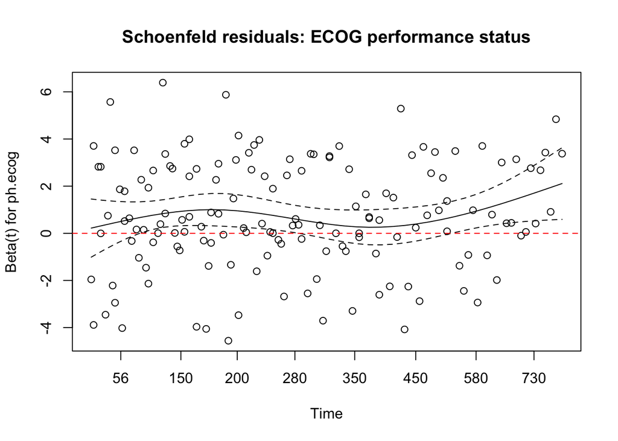

Scaled Schoenfeld residuals for ECOG performance status against time. A roughly flat trend supports the proportional-hazards assumption.

```r
plot(ph_test[3], main = "Schoenfeld residuals: ECOG performance status")
abline(h = 0, col = "red", lty = 2)
```

The **global** test is not significant (p ≈ 0.21), so overall the proportional-hazards assumption is reasonable for this model. The only covariate showing a possible violation is the Karnofsky score (p ≈ 0.03); in practice this could be addressed by stratifying on Karnofsky score or by adding a time-varying effect, but the global fit is acceptable for our purposes.

## 4 Conclusion

Using the NCCTG lung cancer data, the Cox proportional hazards model identified two strong and statistically significant predictors of survival: **sex** and **ECOG performance status**. Female patients had roughly half the hazard of death of male patients, and each step of worsening ECOG status more than doubled the hazard. Age, Karnofsky score, and recent weight loss were not significant once these two factors were included. Diagnostic testing with scaled Schoenfeld residuals indicated that the proportional-hazards assumption held globally, giving us confidence in the estimated hazard ratios.

These results illustrate the strengths of the Cox model that drew us to it during our literature review: it handles censored survival data, produces interpretable hazard ratios without assuming a particular shape for the baseline hazard, and comes with well-established tools for checking its central assumption. A natural extension, noted in our reading on frailty models, would be to account for unobserved heterogeneity between patients — but for these data the standard Cox model already provides a clear and well-fitting description of survival.

## 5 References

Abeysekera, W. W. M., and M. R. Sooriyarachchi. 2009. “Use of Schoenfeld’s Global Test to Test the Proportional Hazards Assumption in the Cox Proportional Hazards Model: An Application to a Clinical Study.” *Journal of the National Science Foundation of Sri Lanka* 37 (1): 41–51.

Cox, D. R. 1972. “Regression Models and Life-Tables.” *Journal of the Royal Statistical Society: Series B (Methodological)* 34 (2): 187–202.

Kaplan, E. L., and Paul Meier. 1958. “Nonparametric Estimation from Incomplete Observations.” *Journal of the American Statistical Association* 53 (282): 457–81.

Loprinzi, Charles L., John A. Laurie, H. Sam Wieand, et al. 1994. “Prospective Evaluation of Prognostic Variables from Patient-Completed Questionnaires. North Central Cancer Treatment Group.” *Journal of Clinical Oncology* 12 (3): 601–7.

Schoenfeld, David. 1982. “Partial Residuals for the Proportional Hazards Regression Model.” *Biometrika* 69 (1): 239–41.

Therneau, Terry M. 2024. *A Package for Survival Analysis in R*. https://CRAN.R-project.org/package=survival.